# Effects of deworming on the prevalence of acute malnutrition and underweight cases among children below 5 years in Kenyan Counties from June 2021 to June 2023

## Exploratory Data Analysis

The foloowing steps were undertaken; Summary statistics of the variables Distribution of the variables Counties with highest rates of acute malnutrition, Underweight children and deworming efforts.

```r
# Summary statistics of the variables
summary(Nutrition_3)
```

```
##     period             county          Total.Dewormed   Acute.Malnutrition
##  Length:1410        Length:1410        Min.   :    97   Min.   :   0.00
##  Class :character   Class :character   1st Qu.:  2454   1st Qu.:   0.00
##  Mode  :character   Mode  :character   Median :  4564   Median :  21.00
##                                        Mean   : 11458   Mean   :  93.83
##                                        3rd Qu.:  8222   3rd Qu.:  92.00
##                                        Max.   :392800   Max.   :4123.00
##   Underweight
##  Min.   :  37.0
##  1st Qu.: 457.2
##  Median : 807.0
##  Mean   :1181.5
##  3rd Qu.:1412.8
##  Max.   :9814.0
```

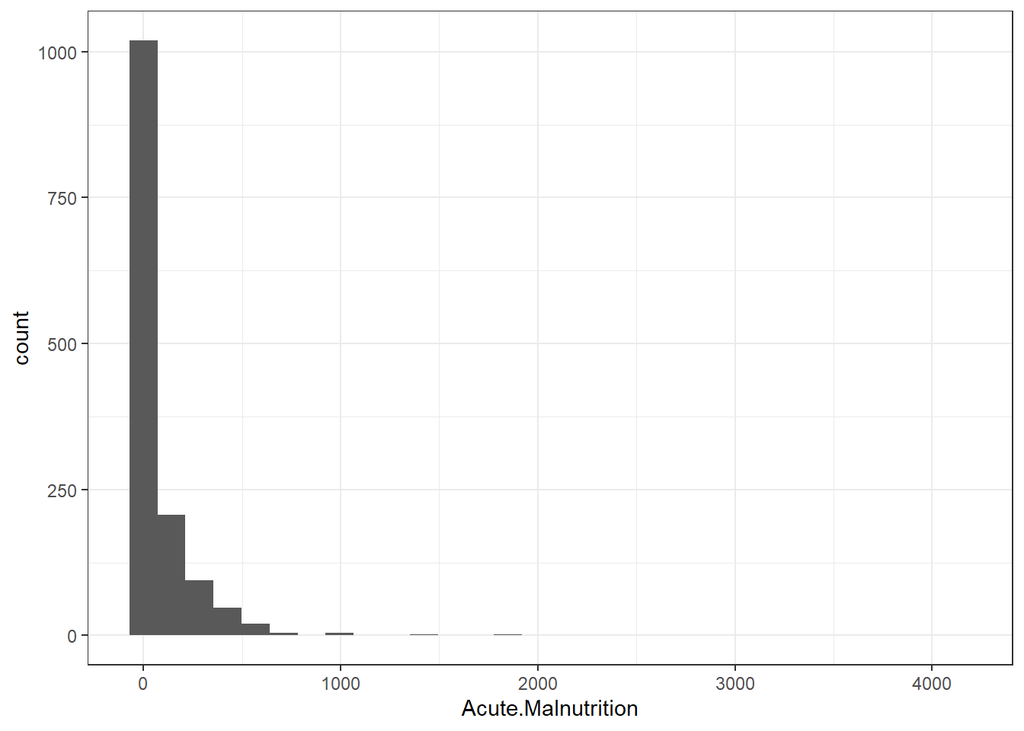

```r
#Distribution of acute malnutrition
ggplot(Nutrition_3, aes(Acute.Malnutrition)) + theme_bw() +
  geom_histogram()+
  labs()
```

It was observerd that the distribution was positively skewed hence log transformation was applied to the data.

```r
skewness(Nutrition_3$Acute.Malnutrition, na.rm = TRUE)
```

```
## [1] 8.277249
```

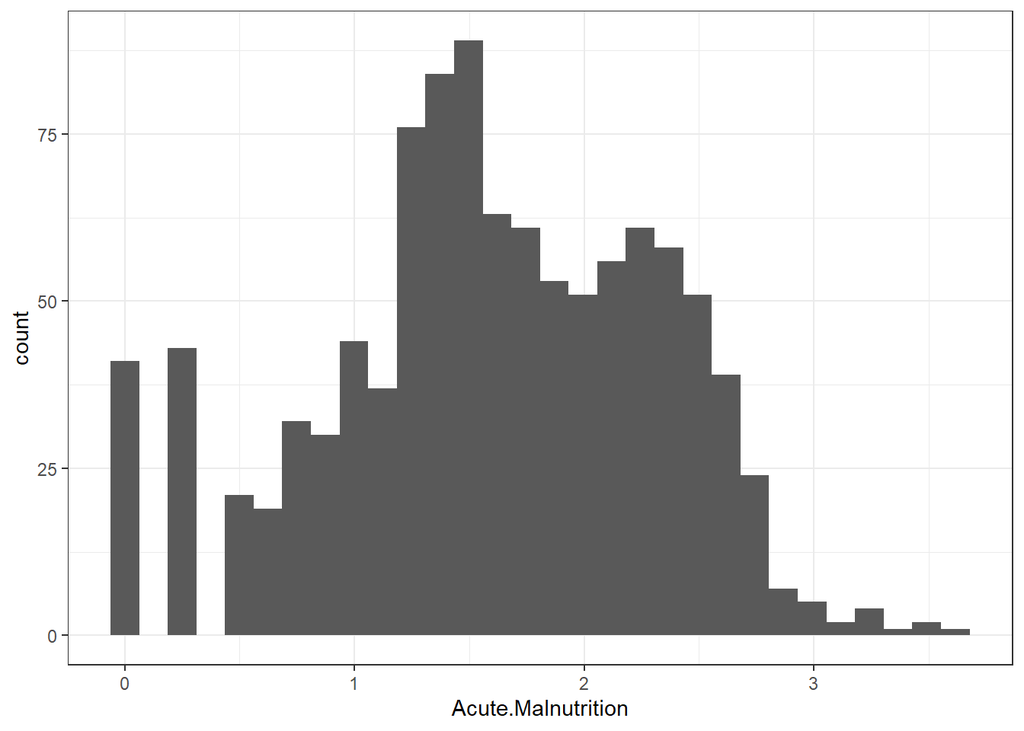

```r
Nutrition_3$Acute.Malnutrition <- log10(Nutrition_3$Acute.Malnutrition)
ggplot(Nutrition_3, aes(Acute.Malnutrition)) + theme_bw() +
  geom_histogram()+
  labs()
```

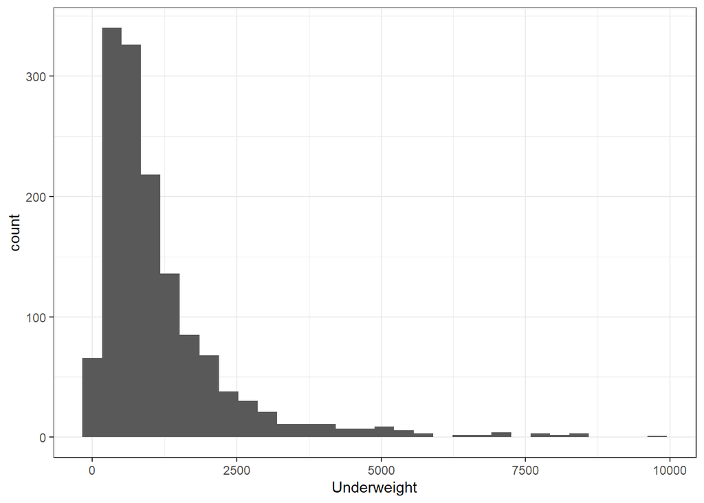

```r
#Distribution of Underweight
ggplot(Nutrition_3, aes(Underweight)) + theme_bw() +
  geom_histogram(bins=30)+
  labs()
```

```r
skewness(Nutrition_3$Underweight, na.rm = TRUE)
```

```
## [1] 2.837642
```

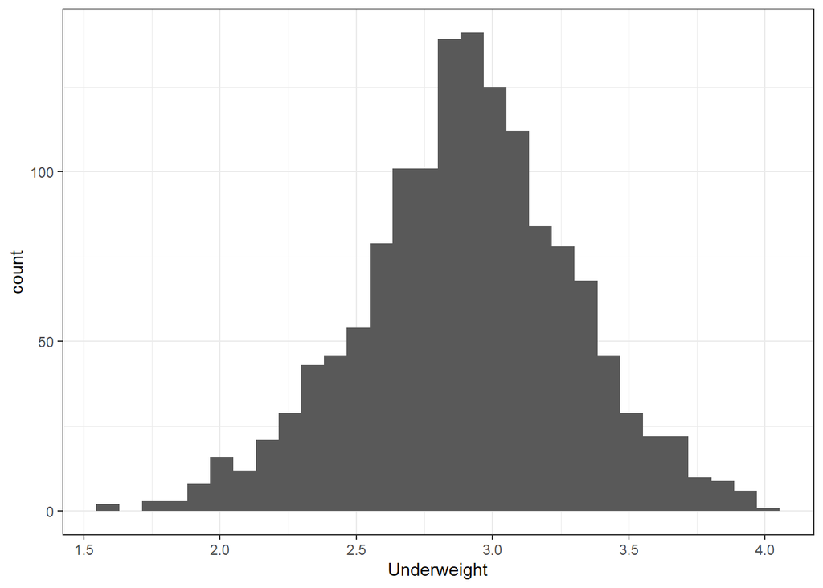

```r
Nutrition_3$Underweight <- log10(Nutrition_3$Underweight)
ggplot(Nutrition_3, aes(Underweight)) + theme_bw() +
  geom_histogram(bins=30)+
  labs()
```

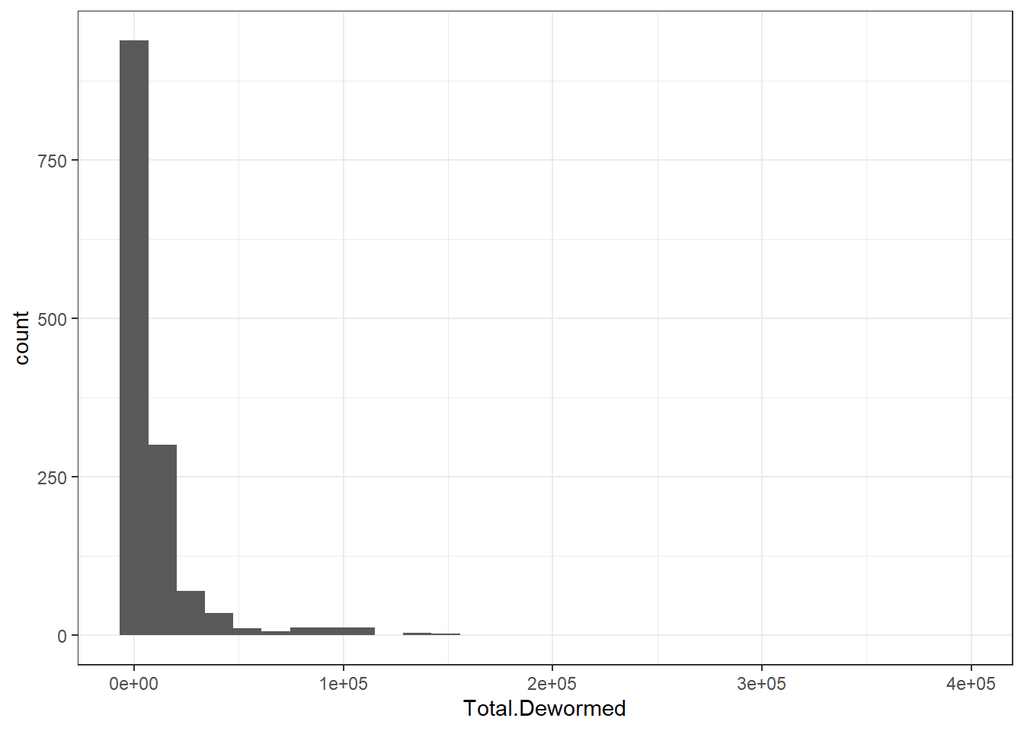

```r
#Distribution of Deworming
ggplot(Nutrition_3, aes(Total.Dewormed)) + theme_bw() +
  geom_histogram(bins=30)+
  labs()
```

```r
skewness(Nutrition_3$Total.Dewormed, na.rm = TRUE)
```

```
## [1] 7.023645
```

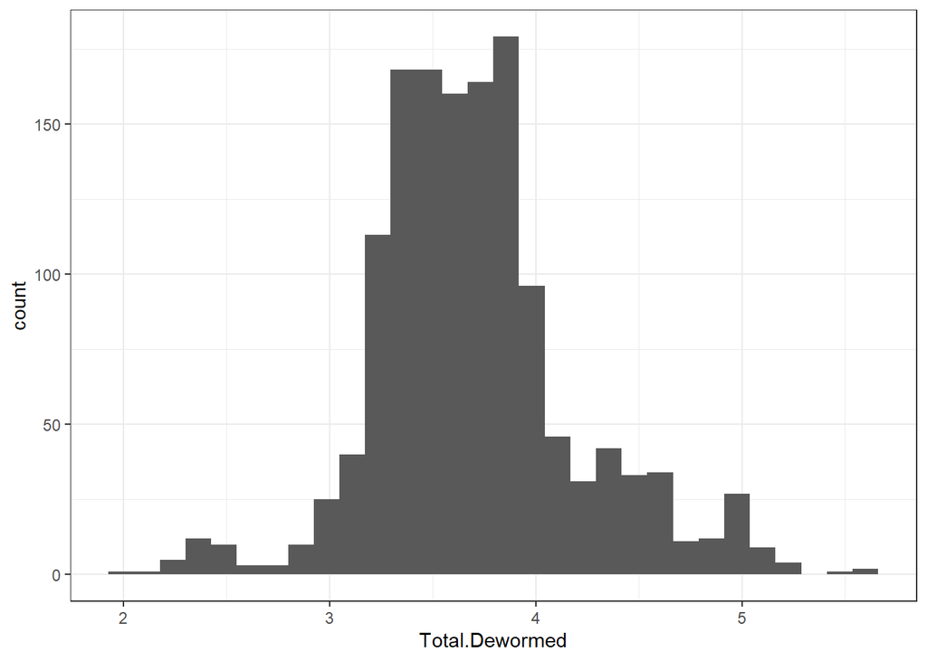

```r
Nutrition_3$Total.Dewormed <- log10(Nutrition_3$Total.Dewormed)
ggplot(Nutrition_3, aes(Total.Dewormed)) + theme_bw() +
  geom_histogram(bins=30)+
  labs()
```

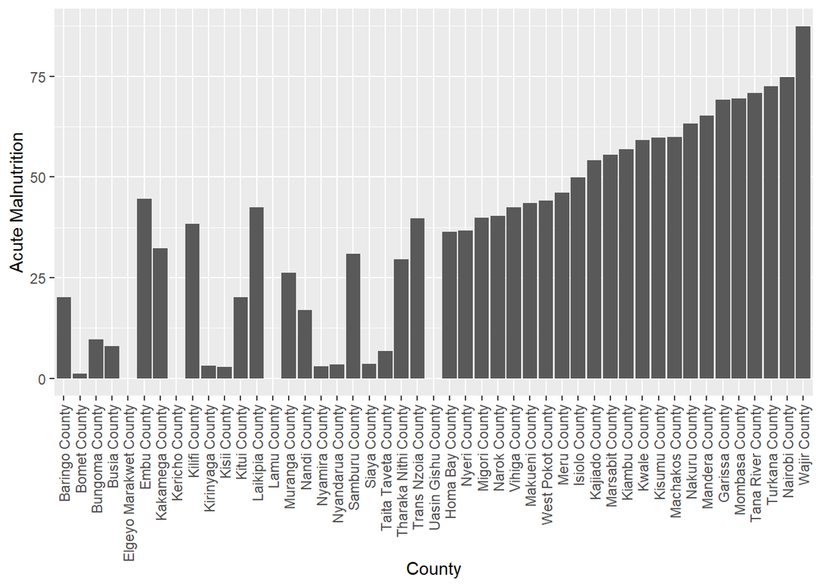

```r
#County with the highest rates of acute malnutrition and Underweight
ggplot(Nutrition_3, aes(x=reorder(county,Acute.Malnutrition), y=Acute.Malnutrition))+
  geom_col()+
  theme(axis.text.x = element_text(angle = 90, vjust = 0.5, hjust=1))+
  labs(x="County", y="Acute Malnutrition")
```

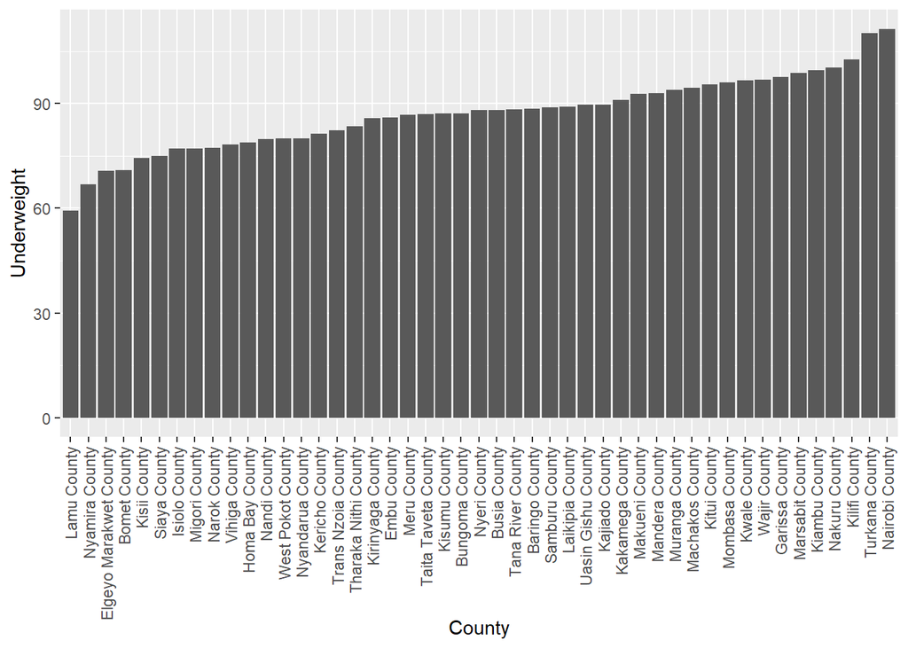

```r
#County with the highest rates of acute malnutrition and Underweight
ggplot(Nutrition_3, aes(x=reorder(county,Underweight), y=Underweight))+
   geom_col()+
   theme(axis.text.x = element_text(angle = 90, vjust = 0.5, hjust=1))+
   labs(x="County", y="Underweight")
```

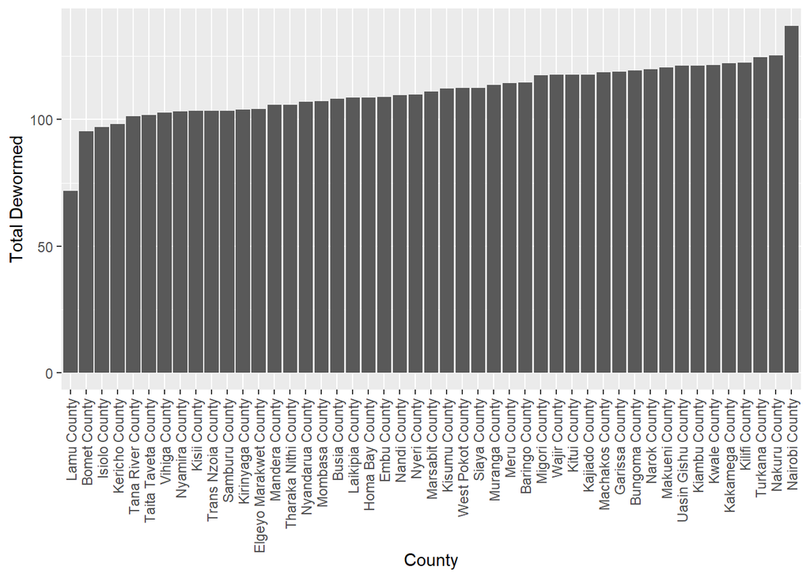

```r
#County with highest rates of Dewormed children
ggplot(Nutrition_3, aes(x=reorder(county,Total.Dewormed), y=Total.Dewormed))+
  geom_col()+
  theme(axis.text.x = element_text(angle = 90, vjust = 0.5, hjust=1))+
  labs(x="County", y="Total Dewormed")
```

## Analysis

1. What is the correlation between deworming practices, acute malnutrition and underweight cases?

```r
corr<- cor(Nutrition_3$Acute.Malnutrition,Nutrition_3$Total.Dewormed, method = 'pearson')
corr
```

```
## [1] NaN
```

```r
corr2<- cor(Nutrition_3$Underweight,Nutrition_3$Total.Dewormed, method = 'pearson')
corr2
```

```
## [1] 0.5374019
```

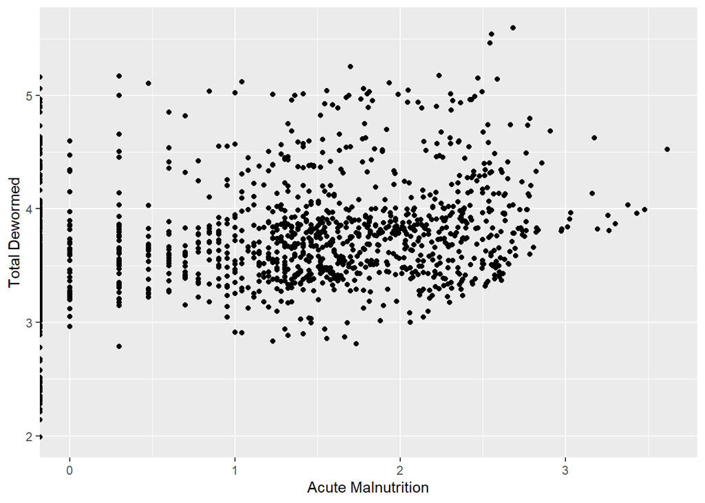

```r
ggplot(Nutrition_3, aes(y=Total.Dewormed, x=Acute.Malnutrition))+
  geom_point()+
  labs(x="Acute Malnutrition", y="Total Dewormed")
```

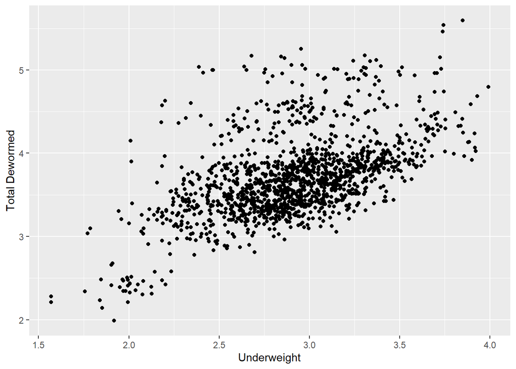

```r
ggplot(Nutrition_3, aes(y=Total.Dewormed, x=Underweight))+
  geom_point()+
  labs(x="Underweight", y="Total Dewormed")
```

2.Are children who are underweight suffering from acute malnutrition?

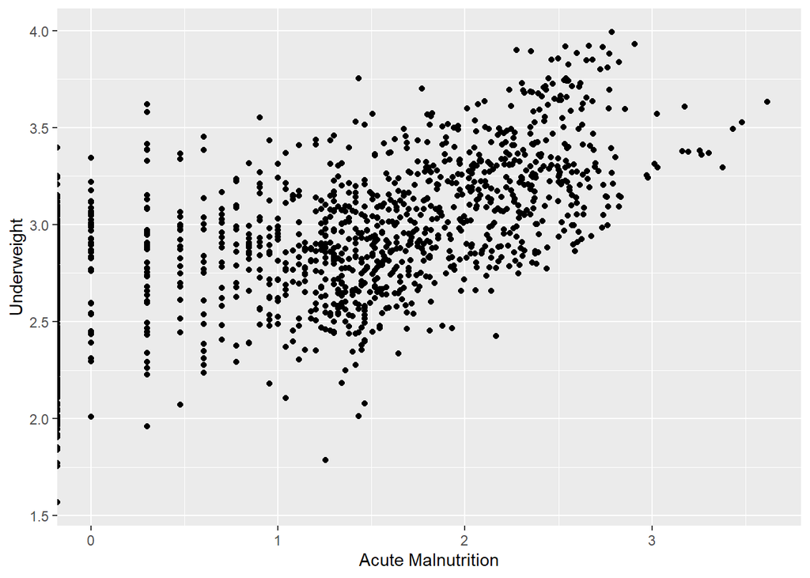

```r
ggplot(Nutrition_3, aes(y=Underweight, x=Acute.Malnutrition))+
  geom_point()+
  labs(x="Acute Malnutrition", y="Underweight")
```

## References

1. CEMA Uon https://github.com/cema-uonbi/internship_task/
2. stackoverflow.com 3.World Health Organisation https://who.int